# hw4

cyber-atlas

March 4, 2019

```r
library(ggplot2)
library(datasets)
library(dplyr)
#ChickWeight

#?ChickWeight
#head(ChickWeight)

#TODO ask and look into the data structure more

#class(ChickWeight)

#summary(ChickWeight)
```

1

```r
#Take the diets of the chickens
#Count the number of rows for each diet save it
#Get the average weight for each diet save it
#Get the sd for the weigh of each diet, save it
weight0 <- ChickWeight %>%group_by(Diet) %>% filter (Time==0) %>% summarize(
    num_chicks = n(),
    avg_weight = mean(weight, na.rm=TRUE),
    sd_weight = sd(weight, na.rm = TRUE)
  )

#print(weight0)
weight0
```

```
## # A tibble: 4 x 4
##   Diet  num_chicks avg_weight sd_weight
##   <fct>      <int>      <dbl>     <dbl>
## 1 1             20       41.4     0.995
## 2 2             10       40.7     1.49
## 3 3             10       40.8     1.03
## 4 4             10       41       1.05
```

2

```r
#sube]
complete <- ChickWeight %>% group_by(Chick) %>% mutate(Measurement_Count =n())

#Now make sure there are only 12 measurements
complete <- complete %>% filter(Measurement_Count == 12)

#print(complete)
head(complete, 3)
```

```
## # A tibble: 3 x 5
## # Groups:   Chick [1]
##   weight  Time Chick Diet  Measurement_Count
##    <dbl> <dbl> <ord> <fct>             <int>
## 1     42     0 1     1                    12
## 2     51     2 1     1                    12
## 3     59     4 1     1                    12
```

3

```r
complete <- complete %>%
  group_by(Chick) %>%
  mutate(weightgain = weight - weight[Time == 0])

head(complete, 3)
```

```
## # A tibble: 3 x 6
## # Groups:   Chick [1]
##   weight  Time Chick Diet  Measurement_Count weightgain
##    <dbl> <dbl> <ord> <fct>             <int>      <dbl>
## 1     42     0 1     1                    12          0
## 2     51     2 1     1                    12          9
## 3     59     4 1     1                    12         17
```

4

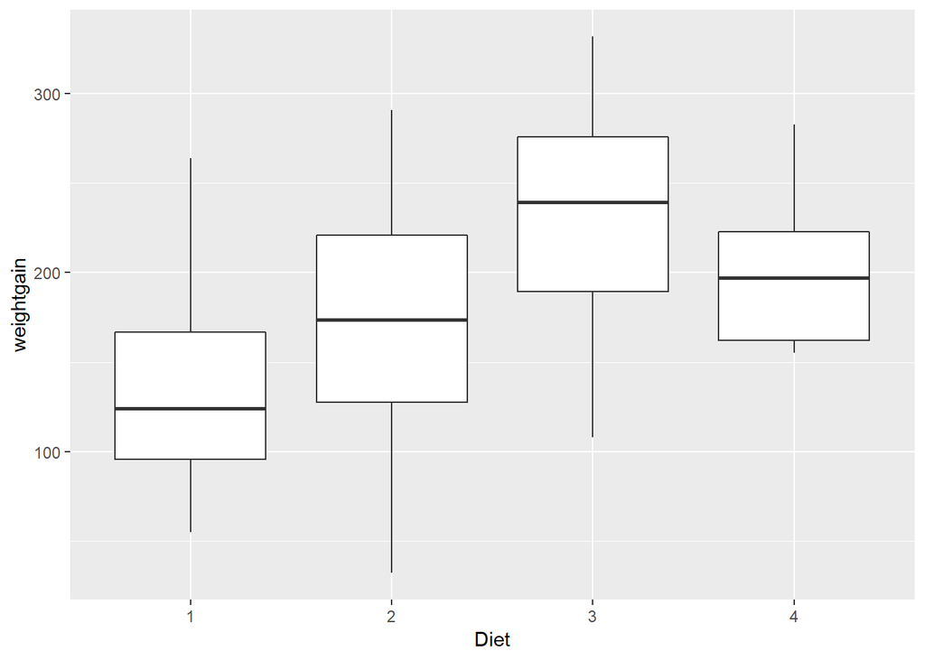

```r
tempDF <- complete %>% filter(Time == 21)
ggplot(tempDF, aes(x=Diet, y=weightgain))+
  geom_boxplot()
```

Diet 2 has the largest distribution of the amount of weight gained by the chickens. Diet 4 seems to have the least, with very few in the bottom IQR. Diet 3 seems to have the highest median and have the highest overall weightgain. Diet 4 can give you the best results with the least amount of risk, because the lowest weight gain was over 150. Diet 3 has a larger overall weight gain and a higher median weight gain, but there were enough chickens below 150 weighgain that they aren’t outliers.

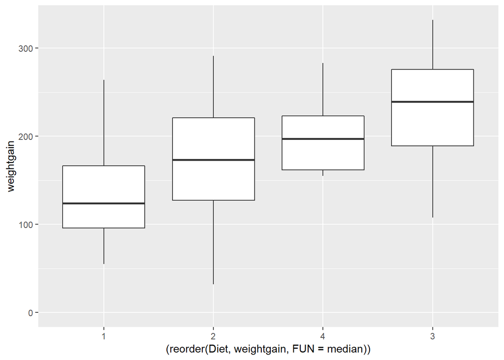

```r
#Used the reoder function to reorder by median
#Added expand_limits to make sure 0 is in the axis range
ggplot(tempDF, aes(x=(reorder (Diet, weightgain, FUN=median)), y=weightgain))+
  geom_boxplot()+
  expand_limits(y=0)
```

5

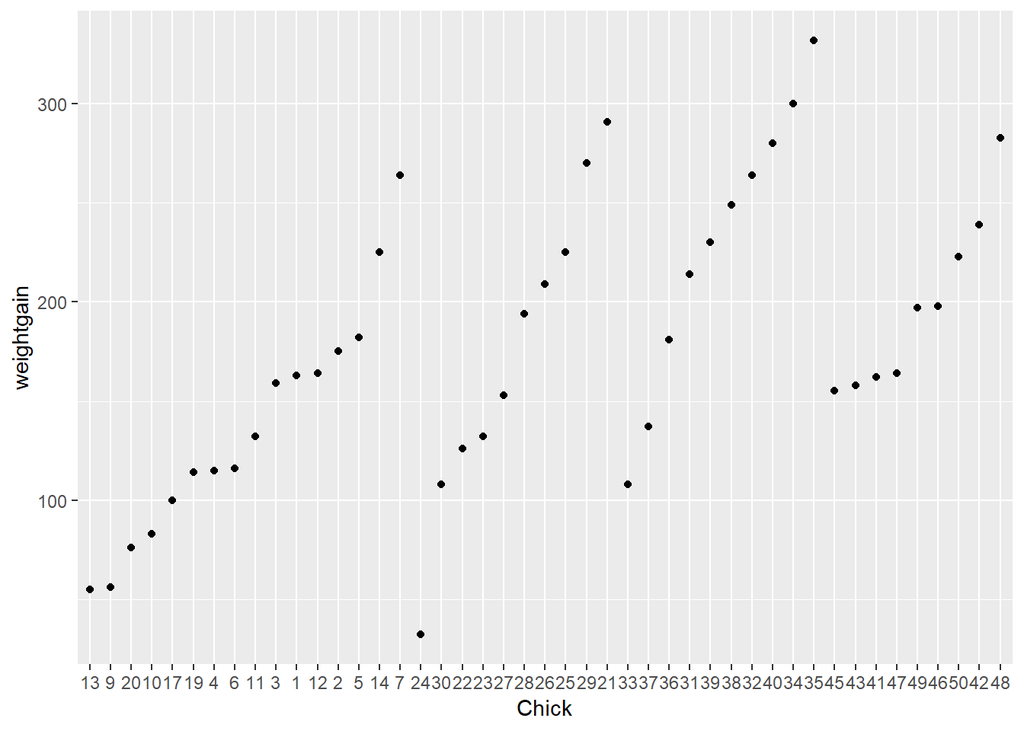

```r
ggplot(tempDF, aes(x=Chick, y=weightgain) )+
  geom_point()
```

```r
temp2df <- tempDF %>% arrange(weightgain, desc(weightgain))

print('Min')
```

```
## [1] "Min"
```

```r
head(temp2df,1)
```

```
## # A tibble: 1 x 6
## # Groups:   Chick [1]
##   weight  Time Chick Diet  Measurement_Count weightgain
##    <dbl> <dbl> <ord> <fct>             <int>      <dbl>
## 1     74    21 24    2                    12         32
```

```r
print('Max')
```

```
## [1] "Max"
```

```r
tail (temp2df,1)
```

```
## # A tibble: 1 x 6
## # Groups:   Chick [1]
##   weight  Time Chick Diet  Measurement_Count weightgain
##    <dbl> <dbl> <ord> <fct>             <int>      <dbl>
## 1    373    21 35    3                    12        332
```

6

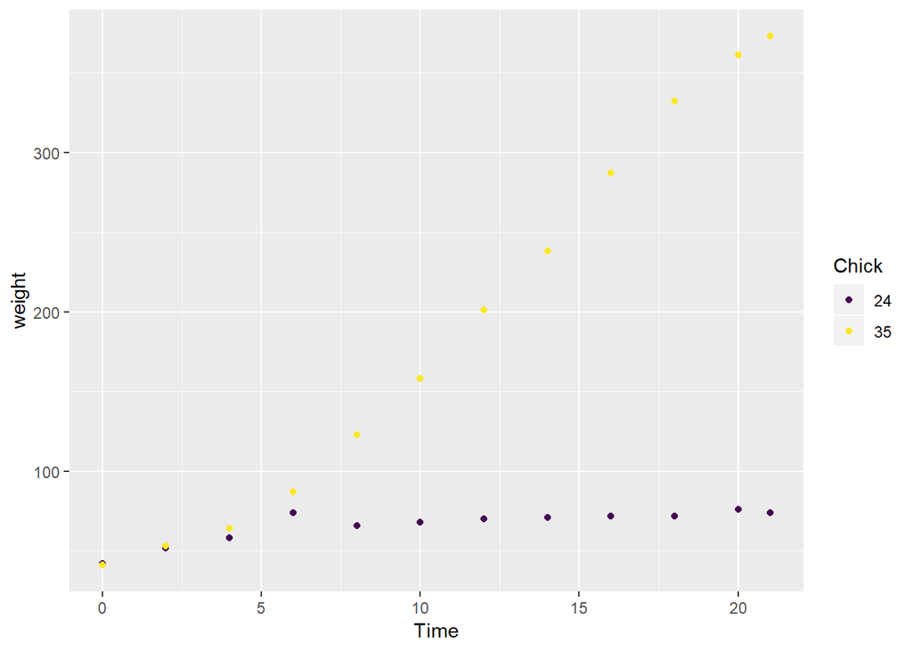

```r
#we know 35 and 24 from problem 5
leastmost <- complete %>% filter(Chick == 35 | Chick == 24)

ggplot(leastmost, aes(x=Time, y=weight, color= Chick)) + geom_point()
```

7

I find it interesting looking at how the time elasped affects the rate of weightgaim